# Part I - (Prosper Loan Data Exploration)

## Introduction

> Introduce the dataset

> This data set contains 113,937 loans with 81 variables on each loan, including loan amount, borrower rate (or interest rate), current loan status, borrower income, and many others.

## Preliminary Wrangling

```python
# import all packages and set plots to be embedded inline
import numpy as np
import pandas as pd
import matplotlib.pyplot as plt
import seaborn as sb

%matplotlib inline
```

```python
#To load and view my data set
Loan= pd.read_csv('prosperLoanData.csv')
Loan.head()
```

|  | ListingKey | ListingNumber | ListingCreationDate | CreditGrade | Term | LoanStatus | ClosedDate | BorrowerAPR | BorrowerRate | LenderYield | ... | LP_ServiceFees | LP_CollectionFees | LP_GrossPrincipalLoss | LP_NetPrincipalLoss | LP_NonPrincipalRecoverypayments | PercentFunded | Recommendations | InvestmentFromFriendsCount | InvestmentFromFriendsAmount | Investors |
| --- | --- | --- | --- | --- | --- | --- | --- | --- | --- | --- | --- | --- | --- | --- | --- | --- | --- | --- | --- | --- | --- |
| 0 | 1021339766868145413AB3B | 193129 | 2007-08-26 19:09:29.263000000 | C | 36 | Completed | 2009-08-14 00:00:00 | 0.16516 | 0.1580 | 0.1380 | ... | -133.18 | 0.0 | 0.0 | 0.0 | 0.0 | 1.0 | 0 | 0 | 0.0 | 258 |
| 1 | 10273602499503308B223C1 | 1209647 | 2014-02-27 08:28:07.900000000 | NaN | 36 | Current | NaN | 0.12016 | 0.0920 | 0.0820 | ... | 0.00 | 0.0 | 0.0 | 0.0 | 0.0 | 1.0 | 0 | 0 | 0.0 | 1 |
| 2 | 0EE9337825851032864889A | 81716 | 2007-01-05 15:00:47.090000000 | HR | 36 | Completed | 2009-12-17 00:00:00 | 0.28269 | 0.2750 | 0.2400 | ... | -24.20 | 0.0 | 0.0 | 0.0 | 0.0 | 1.0 | 0 | 0 | 0.0 | 41 |
| 3 | 0EF5356002482715299901A | 658116 | 2012-10-22 11:02:35.010000000 | NaN | 36 | Current | NaN | 0.12528 | 0.0974 | 0.0874 | ... | -108.01 | 0.0 | 0.0 | 0.0 | 0.0 | 1.0 | 0 | 0 | 0.0 | 158 |
| 4 | 0F023589499656230C5E3E2 | 909464 | 2013-09-14 18:38:39.097000000 | NaN | 36 | Current | NaN | 0.24614 | 0.2085 | 0.1985 | ... | -60.27 | 0.0 | 0.0 | 0.0 | 0.0 | 1.0 | 0 | 0 | 0.0 | 20 |

5 rows × 81 columns

```python
#To view the Loan Original Date

(Loan['LoanOriginationDate'])
```

```
0         2007-09-12 00:00:00
1         2014-03-03 00:00:00
2         2007-01-17 00:00:00
3         2012-11-01 00:00:00
4         2013-09-20 00:00:00
                 ...
113932    2013-04-22 00:00:00
113933    2011-11-07 00:00:00
113934    2013-12-23 00:00:00
113935    2011-11-21 00:00:00
113936    2014-01-21 00:00:00
Name: LoanOriginationDate, Length: 113937, dtype: object
```

```python
#To get the Shape

Loan.shape
```

```
(113937, 81)
```

```python
#To see the secriptive feature

Loan.describe()
```

|  | ListingNumber | Term | BorrowerAPR | BorrowerRate | LenderYield | EstimatedEffectiveYield | EstimatedLoss | EstimatedReturn | ProsperRating (numeric) | ProsperScore | ... | LP_ServiceFees | LP_CollectionFees | LP_GrossPrincipalLoss | LP_NetPrincipalLoss | LP_NonPrincipalRecoverypayments | PercentFunded | Recommendations | InvestmentFromFriendsCount | InvestmentFromFriendsAmount | Investors |
| --- | --- | --- | --- | --- | --- | --- | --- | --- | --- | --- | --- | --- | --- | --- | --- | --- | --- | --- | --- | --- | --- |
| count | 1.139370e+05 | 113937.000000 | 113912.000000 | 113937.000000 | 113937.000000 | 84853.000000 | 84853.000000 | 84853.000000 | 84853.000000 | 84853.000000 | ... | 113937.000000 | 113937.000000 | 113937.000000 | 113937.000000 | 113937.000000 | 113937.000000 | 113937.000000 | 113937.000000 | 113937.000000 | 113937.000000 |
| mean | 6.278857e+05 | 40.830248 | 0.218828 | 0.192764 | 0.182701 | 0.168661 | 0.080306 | 0.096068 | 4.072243 | 5.950067 | ... | -54.725641 | -14.242698 | 700.446342 | 681.420499 | 25.142686 | 0.998584 | 0.048027 | 0.023460 | 16.550751 | 80.475228 |
| std | 3.280762e+05 | 10.436212 | 0.080364 | 0.074818 | 0.074516 | 0.068467 | 0.046764 | 0.030403 | 1.673227 | 2.376501 | ... | 60.675425 | 109.232758 | 2388.513831 | 2357.167068 | 275.657937 | 0.017919 | 0.332353 | 0.232412 | 294.545422 | 103.239020 |
| min | 4.000000e+00 | 12.000000 | 0.006530 | 0.000000 | -0.010000 | -0.182700 | 0.004900 | -0.182700 | 1.000000 | 1.000000 | ... | -664.870000 | -9274.750000 | -94.200000 | -954.550000 | 0.000000 | 0.700000 | 0.000000 | 0.000000 | 0.000000 | 1.000000 |
| 25% | 4.009190e+05 | 36.000000 | 0.156290 | 0.134000 | 0.124200 | 0.115670 | 0.042400 | 0.074080 | 3.000000 | 4.000000 | ... | -73.180000 | 0.000000 | 0.000000 | 0.000000 | 0.000000 | 1.000000 | 0.000000 | 0.000000 | 0.000000 | 2.000000 |
| 50% | 6.005540e+05 | 36.000000 | 0.209760 | 0.184000 | 0.173000 | 0.161500 | 0.072400 | 0.091700 | 4.000000 | 6.000000 | ... | -34.440000 | 0.000000 | 0.000000 | 0.000000 | 0.000000 | 1.000000 | 0.000000 | 0.000000 | 0.000000 | 44.000000 |
| 75% | 8.926340e+05 | 36.000000 | 0.283810 | 0.250000 | 0.240000 | 0.224300 | 0.112000 | 0.116600 | 5.000000 | 8.000000 | ... | -13.920000 | 0.000000 | 0.000000 | 0.000000 | 0.000000 | 1.000000 | 0.000000 | 0.000000 | 0.000000 | 115.000000 |
| max | 1.255725e+06 | 60.000000 | 0.512290 | 0.497500 | 0.492500 | 0.319900 | 0.366000 | 0.283700 | 7.000000 | 11.000000 | ... | 32.060000 | 0.000000 | 25000.000000 | 25000.000000 | 21117.900000 | 1.012500 | 39.000000 | 33.000000 | 25000.000000 | 1189.000000 |

8 rows × 61 columns

```python
#To get all column details
Loan.info()
```

```
<class 'pandas.core.frame.DataFrame'>
RangeIndex: 113937 entries, 0 to 113936
Data columns (total 81 columns):
 #   Column                               Non-Null Count   Dtype
---  ------                               --------------   -----
 0   ListingKey                           113937 non-null  object
 1   ListingNumber                        113937 non-null  int64
 2   ListingCreationDate                  113937 non-null  object
 3   CreditGrade                          28953 non-null   object
 4   Term                                 113937 non-null  int64
 5   LoanStatus                           113937 non-null  object
 6   ClosedDate                           55089 non-null   object
 7   BorrowerAPR                          113912 non-null  float64
 8   BorrowerRate                         113937 non-null  float64
 9   LenderYield                          113937 non-null  float64
```

[output cut: 73 more lines]

```python
(Loan['LoanStatus']).unique()
```

```
array(['Completed', 'Current', 'Past Due (1-15 days)', 'Defaulted',
       'Chargedoff', 'Past Due (16-30 days)', 'Cancelled',
       'Past Due (61-90 days)', 'Past Due (31-60 days)',
       'Past Due (91-120 days)', 'FinalPaymentInProgress',
       'Past Due (>120 days)'], dtype=object)
```

```python
# convert string to ordinal category type

Status = ['Current','Completed','FinalPaymentInProgress', 'Past Due (1-15 days)', 'Past Due (16-30 days)', 'Past Due (31-60 days)','Past Due (61-90 days)','Past Due (91-120 days)','Past Due (>120 days)', 'Chargedoff', 'Defaulted']
ordered_var = pd.api.types.CategoricalDtype(ordered = True, categories = Status)
Loan['LoanSorted'] = Loan['LoanStatus'].astype(ordered_var)
(Loan['LoanSorted']).unique()
```

```
['Completed', 'Current', 'Past Due (1-15 days)', 'Defaulted', 'Chargedoff', ..., 'Past Due (61-90 days)', 'Past Due (31-60 days)', 'Past Due (91-120 days)', 'FinalPaymentInProgress', 'Past Due (>120 days)']
Length: 12
Categories (11, object): ['Current' < 'Completed' < 'FinalPaymentInProgress' < 'Past Due (1-15 days)' ... 'Past Due (91-120 days)' < 'Past Due (>120 days)' < 'Chargedoff' < 'Defaulted']
```

### What is the structure of your dataset?

The data has 113,937 rows with 81 columns, the columns are grouped into 4 data types. Although they are 113,937 rows, not all columns have the same figure, which suggests they are missing data in some columns.

### What is/are the main feature(s) of interest in your dataset?

The major feature of interest for me, is to understand borrower's individual features and how they correllate with the other varibales.

### What features in the dataset do you think will help support your investigation into your feature(s) of interest?

1. Loan Status
2. I would like to find out how employment status relates with loan,
3. To know how the occupation is distributed in the dataframe
4. The state with the most listing
5. The relationshi between the borrowers and homeowners?
6. The Borrowers Rate, Borrowers APR among others.

## Univariate Exploration

```python
#To copy the Dataframe before exploration.

Loan_new=Loan.copy()
```

### 1 what are the loan status like?

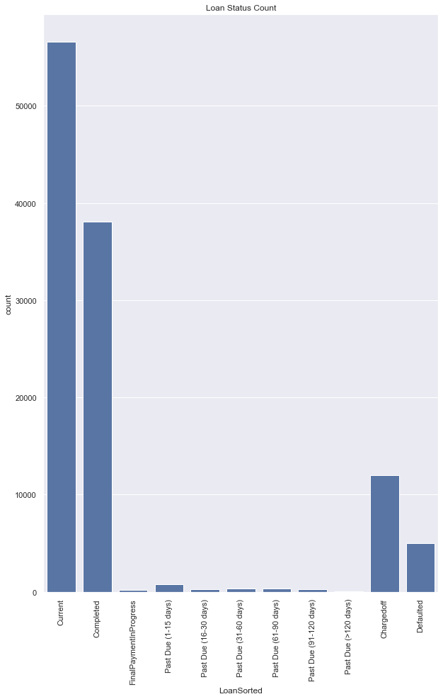

```python
#To select base colour and show the Loan status of the individual.
fig = plt.figure(figsize = [10,15])
base_color = sb.color_palette()[0]
plt.xticks(rotation=90)
sb.countplot(data = Loan_new, x = 'LoanSorted', color = base_color)
plt.title('Loan Status Count')
```

Observation

1. The most common loan status in the dataframe are current. i.e the boorowers are still servicing their debt.
2. The second common loan status in the dataframe are complete.
3. We are able to see the distribution of the other status such as changed off& defaulted,
4. And the loans that areoverdue for payment

### 2 What does the employment status tell us?

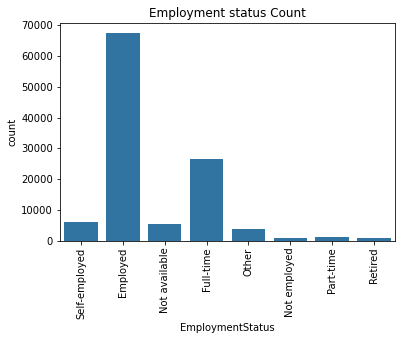

```python
#To visualize the employment status column
sb.countplot(data = Loan_new, x = 'EmploymentStatus', color = base_color);
plt.xticks(rotation = 90);
plt.title('Employment status Count')
```

Observation

1. We can clearly see all the categories of the empluement status.
2. Employed people are the highest category of borrowers in this dataframe.
3. We can see a confusion among the statuses; Full-time, Part-time and Employed.

### 3. What are the occupation distribution?

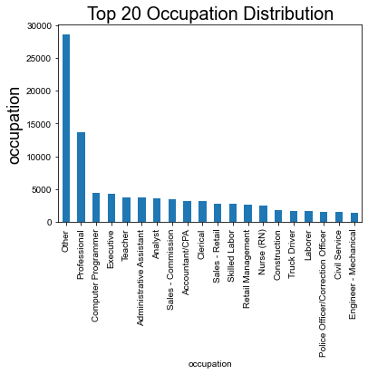

```python
# To capture the distribution of the various category of occupation based on their count.
# Using the first 20.

Loan_new['Occupation'].value_counts()[:20].plot(kind='bar')

plt.title("Top 20 Occupation Distribution",fontsize=20)
plt.xlabel('occupation',fontsize=10)
plt.ylabel("occupation",fontsize= 18)
sb.set_style("whitegrid")
sb.set(rc={'figure.figsize':(20,15)})
```

Observation

1. People with 'other' as their occupation are more in this dataset were more, implying the option to choose from were really limited.
2. The graph captures the distribution of the various category of occupation based on their count.

### 4. What States are the borrowers from?

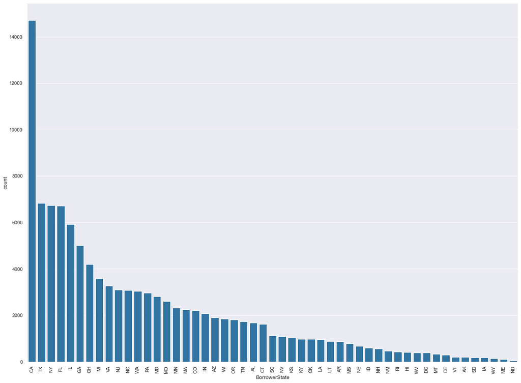

```python
#To group the dataframe in a descending manner
#To plot the diagram using count and state

arrange= Loan_new.groupby('BorrowerState').size().sort_values().index[::-1]

sb.countplot(data = Loan_new, x = 'BorrowerState', color = base_color, order= arrange);
plt.xticks(rotation = 90);
```

Observation

1. CA is the sate with the highest Borrowers
2. NY, FL have the same number of borrowers
3. The difference between the borrowers from CA and the close second is more than half.

### 5. Are the Borrowers all home owners?

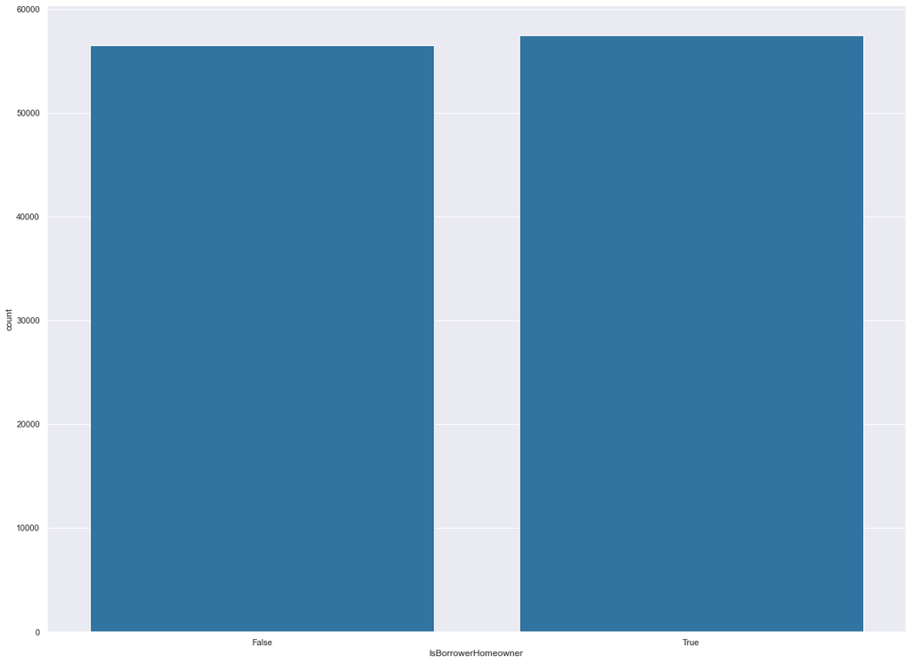

```python
#To know the proportion of borrowers that are home owners

sb.countplot(data = Loan_new, x = 'IsBorrowerHomeowner', color = base_color);
```

Observation

1. Ihe difference between property owners or not is not much among the borrowers.
2. Property is not a yardstick or an eligibiity criteria to get a loan.
3. No they are all not home owners.

### Discuss the distribution(s) of your variable(s) of interest. Were there any unusual points? Did you need to perform any transformations?

> They were no unusal points in my variables of interest as they all looked in order.

### Of the features you investigated, were there any unusual distributions? Did you perform any operations on the data to tidy, adjust, or change the form of the data? If so, why did you do this?

> I had to do some transformation to ensure the graph were visually appealling such as rearranging the variables in a descending order

```python
#To see the new dataframe details
Loan_new.info()
```

```
<class 'pandas.core.frame.DataFrame'>
RangeIndex: 113937 entries, 0 to 113936
Data columns (total 82 columns):
 #   Column                               Non-Null Count   Dtype
---  ------                               --------------   -----
 0   ListingKey                           113937 non-null  object
 1   ListingNumber                        113937 non-null  int64
 2   ListingCreationDate                  113937 non-null  object
 3   CreditGrade                          28953 non-null   object
 4   Term                                 113937 non-null  int64
 5   LoanStatus                           113937 non-null  object
 6   ClosedDate                           55089 non-null   object
 7   BorrowerAPR                          113912 non-null  float64
 8   BorrowerRate                         113937 non-null  float64
 9   LenderYield                          113937 non-null  float64
```

[output cut: 74 more lines]

## Bivariate Exploration

> In this section, investigate relationships between pairs of variables in your data. Make sure the variables that you cover here have been introduced in some fashion in the previous section (univariate exploration).

### 1. What are the variables that correlate more?

```
Loan_samp.shape= (500, 82)
```

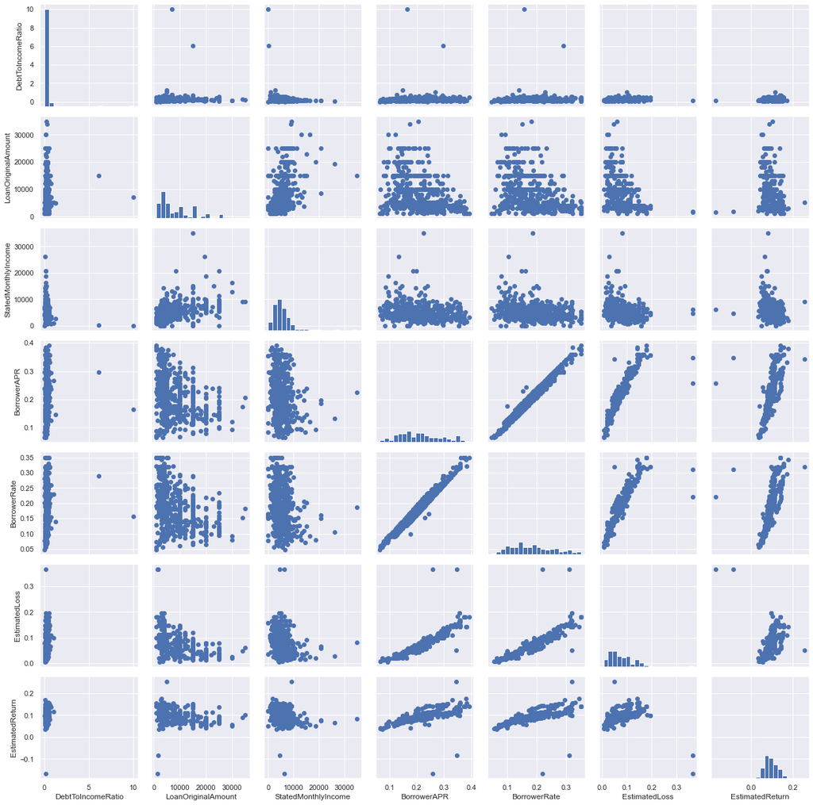

```python
# plot matrix: sample 500 loan samples so that plots are clearer and they render faster
#To allow me to find correlation between variables, in form of any pattern that pops out.

Loan_samp = Loan_new.sample(n=500, replace = False)
print("Loan_samp.shape=",Loan_samp.shape)

numeric_sample= ['DebtToIncomeRatio', 'LoanOriginalAmount', 'StatedMonthlyIncome', 'BorrowerAPR','BorrowerRate','EstimatedLoss', 'EstimatedReturn']
g = sb.PairGrid(data = Loan_samp, vars = numeric_sample)
g = g.map_diag(plt.hist, bins = 20);
g.map_offdiag(plt.scatter)
```

### 2. How do you confirm pairwise correlations present between features in the data ?

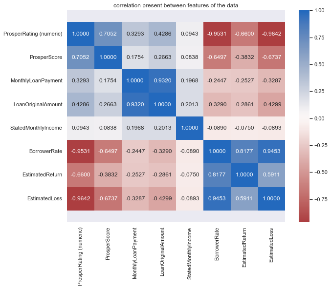

```python
#To determine the correlation between factors that are considered before applying for a loan
correlation_Loan_new = Loan_new[['IncomeRange', 'ProsperRating (numeric)', 'ProsperScore', 'MonthlyLoanPayment','LoanOriginalAmount', 'StatedMonthlyIncome','BorrowerRate','EstimatedReturn','EstimatedLoss']]

# correlation plot
plt.figure(figsize = [10, 8])
sb.heatmap(correlation_Loan_new.corr(), annot = True, fmt = '.4f',
           cmap = 'vlag_r', center = 0)
plt.title('correlation present between features of the data')

#I could not see the complete matrix over here, hence got help via github
# Link- https://github.com/mwaskom/seaborn/issues/1773#issuecomment-546466986
bottom, top = plt.ylim()
bottom += 0.5
top -= 0.5
plt.ylim(bottom, top)
plt.yticks(rotation=0);
plt.show()
```

Observation;

1. It appears that the proper score is highly correlated with the prosper rating
2. Monthly Loan payment is also highly correlated with the Loan Original Amount.

Let's move on to how Borrowers APR and Borrower's rate correlate with some categorial values.

### 3. How does Borrower's APR and Rate correlate with Loan Term, and Homeowner and Employment Status?

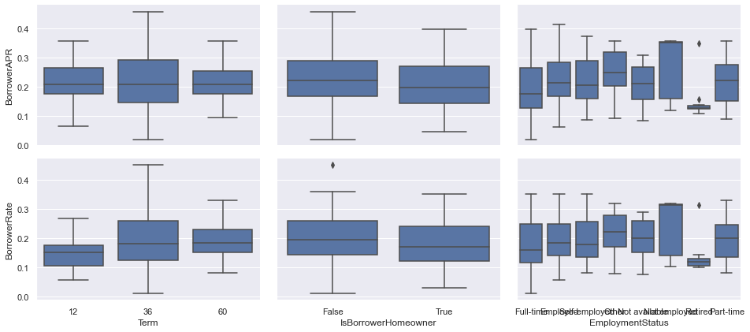

```python
#To plot a graph of Borrower's rate and APR  in relation with Term , Homeowner and Employment Status.

Loan_samp = Loan_new.sample(n=2000, replace = False)

cat= ['Term','IsBorrowerHomeowner', 'EmploymentStatus']

def boxgrid(x, y, **kwargs):
    """ Quick hack for creating box plots with seaborn's PairGrid. """
    default_color = sb.color_palette()[0]
    sb.boxplot(x=x, y=y, color=default_color)

plt.figure(figsize = [15, 10])

g = sb.PairGrid(data = Loan_samp, y_vars = ['BorrowerAPR', 'BorrowerRate'], x_vars = cat,
                height = 3, aspect = 1.5)
g.map(boxgrid)
plt.show();
```

Observation

1. The most common term for the borrowers rate and rate is 36
2. Borrower's rate and APR is higher for non-home owner.

### 4. How does the Loan term Correlate with the Employment Status?

[output not shown]

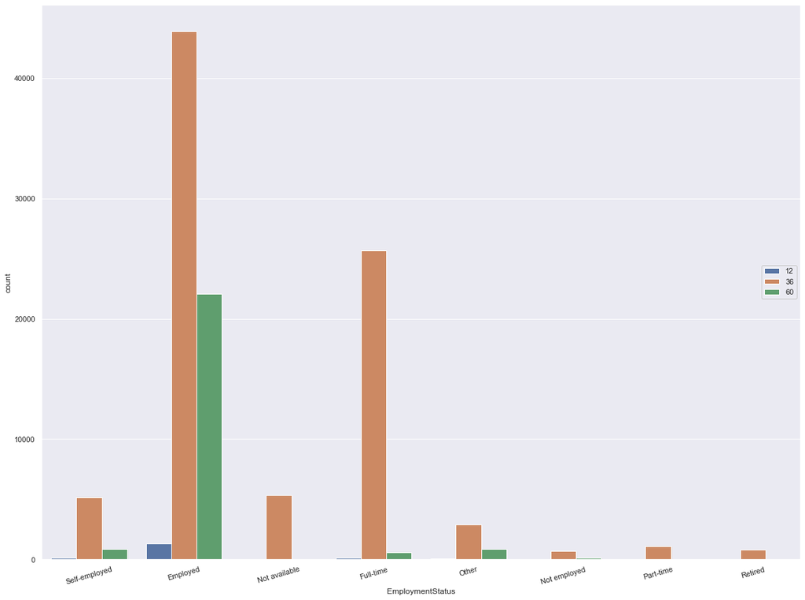

```python
#Visualizing Loan Term vs Employment Status

La= sb.countplot(data= Loan_new, x='EmploymentStatus', hue='Term')
La.legend(loc=5, framealpha=1)
plt.xticks(rotation=16)
```

Observation;

1. Confirming that the most common Loan term among the employment status is 36 months.
2. The only noticaable group with a different employment staus is the Employed,
3. This might imply that they have the capacity to pay back loans with 12 months.

### 5. What is the relationship between the loan amount and loan status?

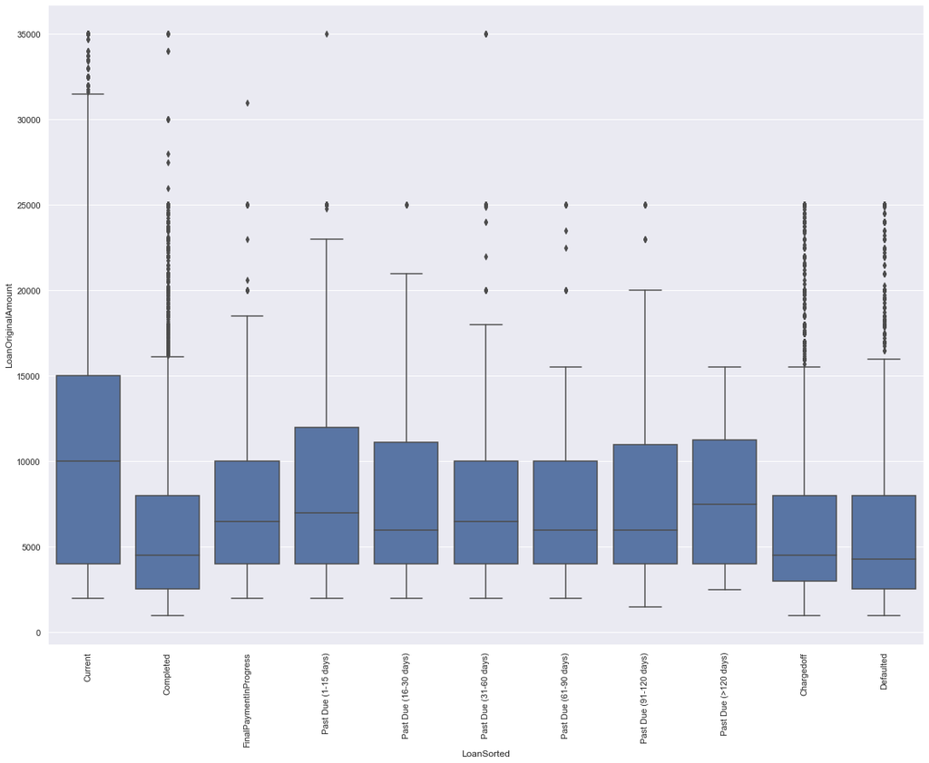

```python
#To show the correlation  between Loan staus and Loan amount
#Box plot

sb.boxplot(data = Loan_new, x = 'LoanSorted', y = 'LoanOriginalAmount', color = base_color)
plt.xticks(rotation = 90);
```

### 6. From the graph above, I'd love to explore the relationship bwteen the Loan Amount and Employment Status

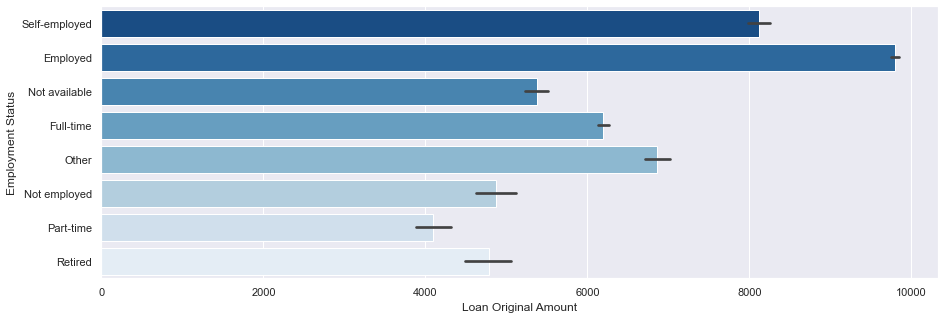

```python
# plotting the graph for the Employment Status and Loan Original Amount
plt.figure(figsize = [15, 5])

base_color = sb.color_palette()[0]
sb.barplot(data = Loan_new, y = 'EmploymentStatus', x = 'LoanOriginalAmount', palette = "Blues_r")
plt.ylabel('Employment Status')
plt.xlabel('Loan Original Amount')
```

Observation

### Talk about some of the relationships you observed in this part of the investigation. How did the feature(s) of interest vary with other features in the dataset?

1 I noticied that employed people took the higher loan anount compared to other employment status.

### Did you observe any interesting relationships between the other features (not the main feature(s) of interest)?

> No i did not.

## Multivariate Exploration

> Create plots of three or more variables to investigate your data even further. Make sure that your investigations are justified, and follow from your work in the previous sections.

### 1. To explore the relationship between Lenderyield, BorrowersRate and Estimated Loss

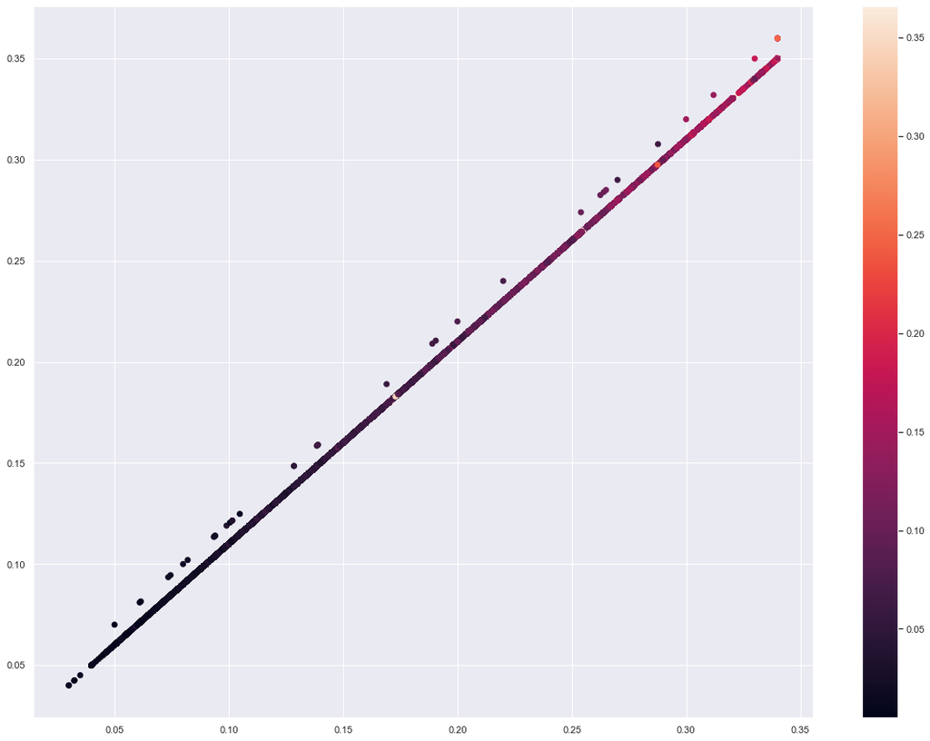

```python
#Plot of a graph with the 3 varibales above.
#scatter plot

plt.scatter(data = Loan_new, x = 'LenderYield', y = 'BorrowerRate', c = 'EstimatedLoss')
plt.colorbar()
```

Observation

1. This shows that the variables are positively correlated. An increase in one variable brings an increase in the other.

### 2. To explore the relationship between Lender yield, BrrowersRate and Estimated Return.

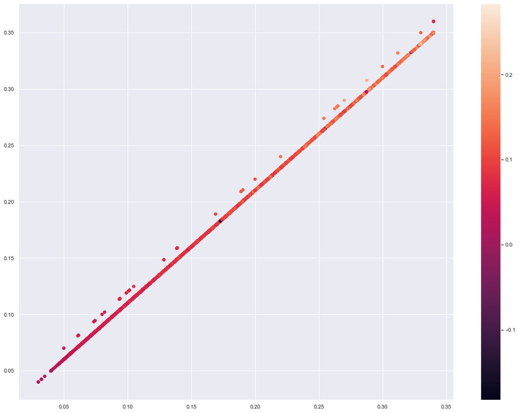

```python
#To show the relationship between the variables above.
# Scatterplot.

plt.scatter(data = Loan_new, x = 'LenderYield', y = 'BorrowerRate', c = 'EstimatedReturn')
plt.colorbar()
```

### 3. To explore the relationship between Loan Status, BorrowersAPR and ProsperRating

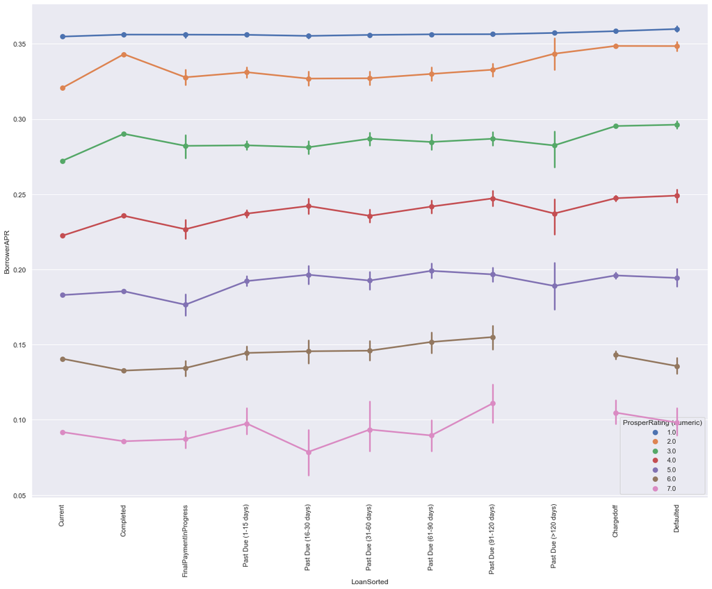

```python
#Pointplot
sb.pointplot(data = Loan_new, x = 'LoanSorted', y = 'BorrowerAPR', hue = 'ProsperRating (numeric)')
plt.xticks(rotation = 90);
```

Observation

### 4. To compare the Year, with the Borrower's rate and Homeowner Status

```python
# Convert 'ListingCreationDate' type from str to datetime
Loan_new['ListingCreationDate']=pd.to_datetime(Loan_new['ListingCreationDate'])

# Extract date information from ListingCreationDate column
Loan_new['date'] = Loan_new['ListingCreationDate'].dt.date

# Extract year information from ListingCreationDate column
Loan_new['year']= Loan_new['ListingCreationDate'].dt.year

# Extract month information from ListingCreationDate column
Loan_new['month'] = Loan_new['ListingCreationDate'].dt.month

# Convert 'date' type from str to datetime
Loan_new['date']=pd.to_datetime(Loan_new['date'])
# df_selected['year']=pd.to_datetime(df_selected['year'])

# Drop unused column
Loan_new.drop(['ListingCreationDate'], axis=1, inplace=True)
```

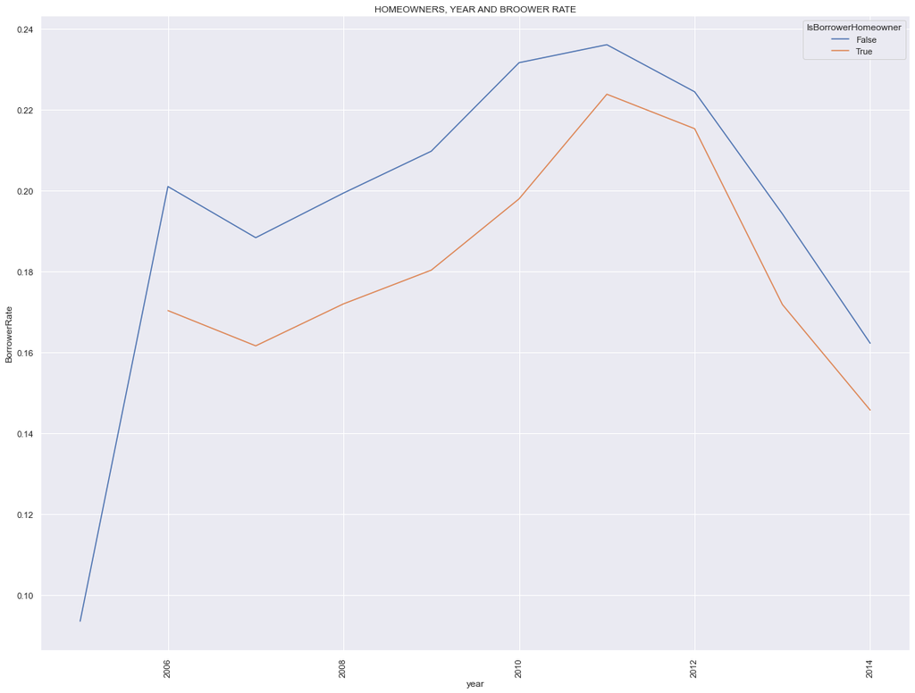

```python
#To plot the graph showing the relationship between the 3 variables above.

plt.figure(figsize=(20,15))
g=sb.lineplot(data=Loan_new, x='year', y='BorrowerRate', hue='IsBorrowerHomeowner',ci=None);
plt.xticks(rotation = 90);
plt.title('HOMEOWNERS, YEAR AND BROOWER RATE');
```

Observation

1. It validates the notion that the Borrower's rate are cheaper for the home owners as from 2006.

### 5. How does Term, propser rate and Borrower's rate correlate?

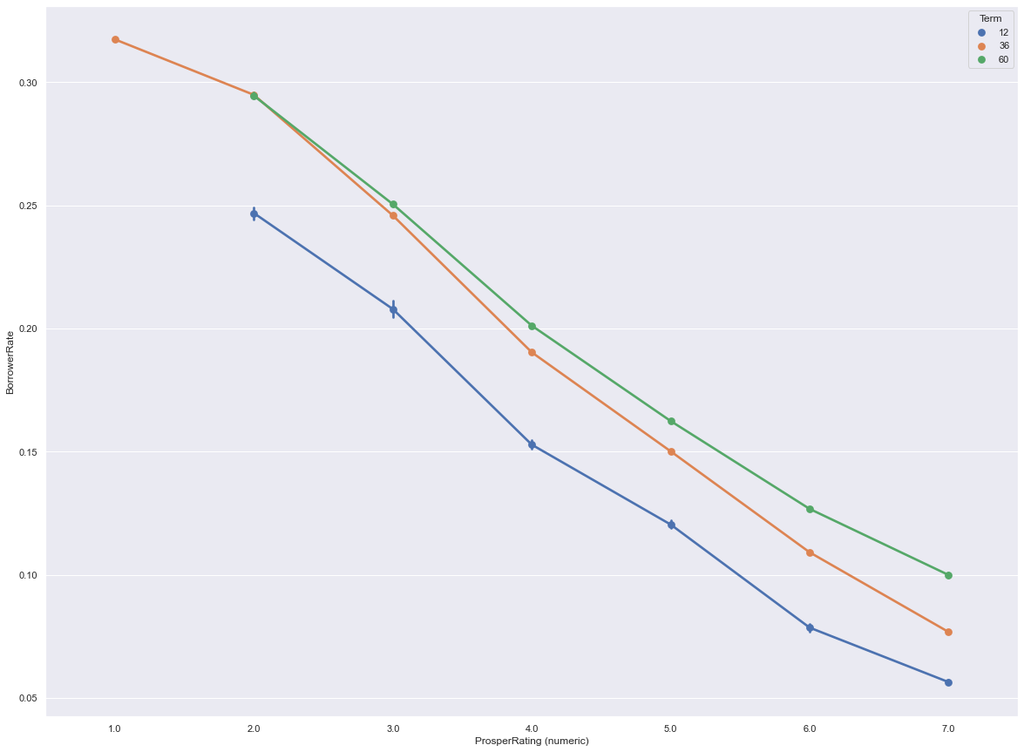

```python
#To Find the relationship between the Term, Prosper
#plot pointplot
fig = plt.figure(figsize = [20,15])
ax = sb.pointplot(data = Loan_new, x = 'ProsperRating (numeric)', y = 'BorrowerRate', hue = 'Term')
```

### Talk about some of the relationships you observed in this part of the investigation. Were there features that strengthened each other in terms of looking at your feature(s) of interest?

> It confirmed that the borrowers rate is an import detail to get many answers to the my analysis.

### Were there any interesting or surprising interactions between features?

> Yes they were. The insights from the estimated return vs estimated loss.

## Conclusions

> The data revealed the intricacies between the financial and individual features among those who accessed the loan from prosper. The visualization helped them stand out.